# Overview

This document outlines the steps for analyzing solid-state <sup>13</sup>C CP/MAS NMR spectra using the `SOMnmR` package in R. The package was developed by Luis Colocho at the Technical University of Munich. You can find the package and its documentation here: https://github.com/LuisCol8/SOMnmR and a peer-reviewed publication describing the methods here: https://doi.org/10.1029%2F2024JG008288.

Full citation: Colocho Hurtarte, L. C., Garcia‐Franco,N., Villalba Ayala, G., Prietzel, J., &Koegel‐Knabner, I. (2025). SOMnmR: An R package for analyzing CP MAS <sup>13</sup>C NMR spectra of environmental samples. *Journal of Geophysical Research: Biogeosciences*, 130, e2024JG008288.

# Basic Integration of NMR Data

modified from SOMnmR “Basic example” vignette: https://github.com/LuisCol8/SOMnmR/blob/main/how-to-use.md

The following code chunk will load and integrate all CP/MAS <sup>13</sup>C NMR spectra stored as comma-separated value (.csv) files in the specified folder. Note that the resulting integrals are not yet spinning side-band (SSB) corrected. There are three integration methods available in the `int_nmr` function: “4region”, “Bonanomi”, and “MMM”. “4region” divides the spectrum into four chemical shift regions:

| Alkyl | 0–45 ppm |
| --- | --- |
| O/N-Alkyl | 45–110 ppm |
| Aryl | 110–160 ppm |
| Carboxyl | 160–210 ppm |

“Bonanomi” uses 7 integration regions defined in [Bonanomi et al., 2011](https://doi.org/10.1111/j.1469-8137.2011.03765.x). This method is used to investigate detailed chemical changes in organic materials, such as during litter decomposition.

| Alkyl | 0–45 ppm |
| --- | --- |
| N-Alkyl/methoxy | 46–60 ppm |
| O-Alkyl | 61–90 ppm |
| Di-O-Alkyl | 91–110 ppm |
| Aromatic | 111–140 ppm |
| Phenolic | 141–160 ppm |
| Carboxyl | 161–190 ppm |

The “MMM” method uses a set of seven integration ranges similar to the “Bonanomi” method, tailored for input into the mixing models based on previous work from [Nelson et al. (1999)](https://doi.org/10.1071/S98076), [Baldock et al. (2004)](https://doi.org/10.1016/j.marchem.2004.06.016) and [Nelson and Baldock (2005)](https://doi.org/10.1007/s10533-004-0076-3).

| Alkyl | −10–45 ppm |
| --- | --- |
| N-Alkyl/methoxy | 45–60 ppm |
| O-Alkyl | 60–95 ppm |
| Di-O-Alkyl | 95–110 ppm |
| Aromatic | 110–145 ppm |
| Phenolic | 145–165 ppm |
| Carbonyl | 165–210 ppm |

To perform the MMM analysis, the SOMnmR package needs both the integrated signal intensities and the molar C:N values of the samples. For now, since I don’t have C:N values for these samples, I will just use the “Bonanomi” method.

```r
setwd(csv_folder)

## list all the files
files <- list.files()

## list all the files that end with .csv
files <- files[grep("\\.csv$", files)]

# Load data, choose either  "Bruker" (standard Bruker file), "coma" (coma separated value), "tab" (tab separated value)
spec <- read_raw_spec(files, filetype = "coma")

# Integrate the whole data set, NMRmeth can be "4region", "Bonanomi" and "MMM". I will chose Bonanomi.
# For this you will need to input the magnetic field of your NMR machine and the spinning frequency of the probe.
# In this example we used an NMR of 500 MHz and a spinning frequency of 10,000 Hz.

# Suppress progress bar output
invisible(capture.output(
  Integralregions <- int_nmr(spec, NMRmeth = "Bonanomi", NMR_field = 500, NMR_rotation = 10000)
))

# Display results in the knitted output
print(paste("Integrated", length(Integralregions), "spectra"))
```

```
## [1] "Integrated 25 spectra"
```

```r
# Show the first spectrum's integral table
integral_table <- Integralregions[[1]][["data"]][["Integral"]]
# Round numeric columns to 3 decimal places
integral_table[] <- lapply(integral_table, function(x) if(is.numeric(x)) round(x, 3) else x)
knitr::kable(integral_table,
             caption = "Example: Integral regions for first spectrum")
```

Example: Integral regions for first spectrum

| Integral | From | To | Component | Component_index | Component_ssb | sbb_index | ssb_ofset |
| --- | --- | --- | --- | --- | --- | --- | --- |
| 0.246 | -80 | -70 | NA | NA | Alkyl | 1 | Low |
| 0.575 | -70 | -50 | NA | NA | Alkyl | 2 | Low |
| 0.718 | -50 | -35 | NA | NA | Alkyl | 3 | Low |
| 1.006 | -35 | -20 | NA | NA | Methoxy/N-Alkyl | 4 | Low |
| 2.351 | -20 | 0 | NA | NA | O-Alkyl | 5 | Low |
| 1.399 | 0 | 10 | Alkyl | 1 | O-Alkyl | 6 | Low |
| 5.988 | 10 | 30 | Alkyl | 2 | Di-O-Alkyl | 7 | Low |
| 5.426 | 30 | 45 | Alkyl | 3 | Aromatic | 8 | Low |
| 11.033 | 45 | 60 | Methoxy/N-Alkyl | 4 | Aromatic | 9 | Low |
| 39.739 | 60 | 80 | O-Alkyl | 5 | Phenolic | 10 | Low |
| 9.465 | 80 | 90 | O-Alkyl | 6 | Alkyl | 1 | High |
| 11.706 | 90 | 110 | Di-O-Alkyl | 7 | Alkyl | 2 | High |
| 3.606 | 110 | 125 | Aromatic | 8 | Alkyl | 3 | High |
| 2.070 | 125 | 140 | Aromatic | 9 | Methoxy/N-Alkyl | 4 | High |
| 2.403 | 140 | 160 | Phenolic | 10 | O-Alkyl | 5 | High |
| 0.783 | 160 | 170 | Amide/Carboxyl | 11 | O-Alkyl | 6 | High |
| 1.289 | 170 | 190 | Amide/Carboxyl | 12 | Di-O-Alkyl | 7 | High |
| 0.268 | 190 | 205 | NA | NA | Aromatic | 8 | High |
| 0.099 | 205 | 220 | NA | NA | Aromatic | 9 | High |
| -0.107 | 220 | 240 | NA | NA | Phenolic | 10 | High |
| -0.036 | 240 | 250 | NA | NA | Amide/Carboxyl | 11 | High |
| -0.026 | 250 | 270 | NA | NA | Amide/Carboxyl | 12 | High |

# Correcting for Spinning Side Bands (SSB)

“We now know how to load a spectrum a perform a simple integration. There is a wraped function that performs the integration, and corrects for the SSBs. The example follows”

```r
# load necessary packages
  library(minpack.lm)
  library(quadprog)
  library(pracma)
  library(ggplot2)
  library(data.table)
  library(dplyr)
  library(IntervalSurgeon)
  library(SOMnmR)

# Source modified region_calc function that adds Suberin region
code_folder <- "/Users/adrianneseiden/Documents/adrianne-code"
# # Debug: Print the full path and check if file exists
# print(paste("Attempting to source:", file.path(code_folder, "region_calc_suberin.R")))
# print(paste("File exists:", file.exists(file.path(code_folder, "region_calc_suberin.R"))))
source(file.path(code_folder, "region_calc_suberin.R"))

# load data
## set working directory
csv_folder <- file.path(box_base, "Salk Institute Project/AKS Salk files/Adrianne_NMR/MNova-CSVs")
outputs_folder <- file.path(box_base, "Salk Institute Project/AKS Salk files/Adrianne_NMR/NMR_analysis_outputs")

## go to directory containing all spectra
setwd(csv_folder)

## list all the files
files <- list.files()

## list all the files that end with .csv
files <- files[grep("\\.csv$", files)]

# Load data, choose either  "Bruker" (standard Bruker file), "coma" (coma separated value), "tab" (tab separated value
spec <- read_raw_spec(files, filetype = "coma")

# Integrate and correct for the SSB of the whole data set, NMRmeth can be "4region", "Bonanomi" and "MMM".
# I will chose Bonanomi.
# For this you will need to input the magnetic field of your NMR machine and the spinning frequency of the probe.
# For this research I used an NMR of 500 MHz and a spinning frequency of 10000 Hz.

# Suppress progress bar output
# Using region_calc_suberin which adds Suberin region (28-35 ppm)
invisible(capture.output(
  IntegralSSBc <- region_calc_suberin(spec, NMRmeth = "Bonanomi", NMR_field = 500, NMR_rotation = 10000)
))

# Debug: Check if Suberin column exists in first result
if (!is.null(IntegralSSBc[[1]]$Suberin)) {
  print("Suberin column successfully added!")
  print(paste("Suberin value for first sample:", round(IntegralSSBc[[1]]$Suberin, 3)))
} else {
  print("Warning: Suberin column not found in results")
  print(paste("Columns in result:", paste(names(IntegralSSBc[[1]]), collapse=", ")))
}
```

```
## [1] "Suberin column successfully added!"
## [1] "Suberin value for first sample: 4.877"
```

```r
# Convert character columns to numeric in each data frame (except 'name')
IntegralSSBc <- lapply(IntegralSSBc, function(df) {
  for(col in names(df)) {
    if(col != "name") {
      df[[col]] <- as.numeric(df[[col]])
    }
  }
  return(df)
})
#To view the output of a single spectrum
# View(IntegralSSBc[[1]])

# Round and display first spectrum
ssb_table <- IntegralSSBc[[1]]
ssb_table[] <- lapply(ssb_table, function(x) if(is.numeric(x)) round(x, 3) else x)
knitr::kable(ssb_table,
             caption = "Example: SSB-corrected output for a single spectrum")
```

Example: SSB-corrected output for a single spectrum

| name | Alkyl | Amide.Carboxyl | Aromatic | Di.O.Alkyl | Methoxy.N.Alkyl | O.Alkyl | Phenolic | Suberin |
| --- | --- | --- | --- | --- | --- | --- | --- | --- |
| AS001_13Cwheat_wk0_root_nt8192 | 15.632 | 1.95 | 4.688 | 11.138 | 12.954 | 53.799 | -0.162 | 4.877 |

```r
#Generate a table with all the results instead of having each in a list
Integrall <- NULL
for (i in 1:length(IntegralSSBc)) {
  Integral <- data.frame(IntegralSSBc[[i]], stringsAsFactors = FALSE)
  Integrall <- rbind(Integrall, Integral)
}

# Convert all columns except 'name' to numeric and round to 3 decimals
for(col in names(Integrall)) {
  if(col != "name") {
    Integrall[[col]] <- round(as.numeric(Integrall[[col]]), 3)
  }
}

# Display all results
knitr::kable(Integrall,
             caption = "Results table: All spectra SSB-corrected integrals") %>%
  kableExtra::kable_styling()
```

Results table: All spectra SSB-corrected integrals

| name | Alkyl | Amide.Carboxyl | Aromatic | Di.O.Alkyl | Methoxy.N.Alkyl | O.Alkyl | Phenolic | Suberin |
| --- | --- | --- | --- | --- | --- | --- | --- | --- |
| AS001_13Cwheat_wk0_root_nt8192 | 15.632 | 1.950 | 4.688 | 11.138 | 12.954 | 53.799 | -0.162 | 4.877 |
| AS012_13Csoy_wk10_root_nt10240 | 12.457 | 4.310 | 7.485 | 12.630 | 9.667 | 51.761 | 1.689 | 4.795 |
| AS029_13Cwheat_wk10_root_nt1024 | 9.467 | 4.999 | 7.798 | 13.077 | 8.995 | 52.565 | 3.098 | 3.693 |
| AS029_13Cwheat_wk40_root_nt16384 | 11.519 | 5.059 | 17.420 | 11.140 | 8.806 | 40.015 | 6.040 | 5.969 |
| AS030_13Csoy_wk10_root_nt8192 | 8.764 | 2.616 | 7.667 | 13.622 | 9.198 | 56.599 | 1.534 | 3.839 |
| AS030_13Csoy_wk40_root_nt32768 | 13.010 | 6.392 | 12.997 | 11.181 | 9.760 | 41.860 | 4.800 | 5.729 |
| AS050_13Csoy_wk0_root_nt1024 | 11.708 | 7.557 | 9.627 | 12.642 | 8.082 | 46.778 | 3.605 | 5.134 |
| AS052_13CnoPlant_wk40_root_nt32768 | 11.972 | 5.603 | 16.056 | 11.418 | 9.232 | 39.928 | 5.793 | 5.568 |
| AS053_13Cwheat_wk10_root_nt16384 | 7.332 | 2.907 | 13.043 | 14.218 | 8.908 | 50.112 | 3.480 | 3.849 |
| AS053_13Cwheat_wk40_root_nt32768 | 10.635 | 4.802 | 18.183 | 11.280 | 9.461 | 39.699 | 5.940 | 5.109 |
| AS055_13Crice_wk40_root_nt16384 | 8.740 | 4.530 | 10.819 | 12.793 | 8.303 | 50.388 | 4.427 | 4.120 |
| AS079_13Crice_wk0_root_nt32768 | 11.789 | 5.218 | 11.486 | 12.452 | 9.137 | 46.344 | 3.574 | 4.819 |
| AS080_13Csoy_wk10_root_nt8192 | 10.831 | 5.169 | 11.634 | 12.684 | 9.863 | 46.450 | 3.370 | 4.737 |
| AS080_13Csoy_wk40_root_nt4096 | 8.102 | 3.900 | 11.991 | 11.551 | 10.659 | 48.681 | 5.116 | 3.278 |
| AS087_13Crice_wk10_root_nt22528 | 8.858 | 4.428 | 11.254 | 12.820 | 10.006 | 48.651 | 3.984 | 3.557 |
| AS087_13Crice_wk40_root_nt1024 | 8.948 | 4.461 | 9.132 | 12.762 | 8.005 | 52.972 | 3.720 | 4.107 |
| AS094_13Csoy_wk40_root_nt1024 | 10.186 | 4.327 | 11.022 | 11.404 | 9.785 | 48.698 | 4.579 | 4.757 |
| AS103_13Crice_wk0_root_nt5464 | 5.176 | 5.405 | 13.914 | 13.931 | 6.217 | 50.092 | 5.266 | 2.861 |
| AS119_13Crice_wk10_root_nt24576 | 9.460 | 4.407 | 9.710 | 13.093 | 8.401 | 51.741 | 3.188 | 3.981 |
| SC032_13Cwheat_wk0_root_nt2048_d1_2 | 2.706 | 4.526 | 11.456 | 14.824 | 5.649 | 55.399 | 5.440 | 1.374 |
| SC055_13Crice_wk10_root_nt2048 | 10.857 | 2.958 | 6.683 | 12.650 | 10.726 | 54.310 | 1.817 | 3.824 |
| SC062_13Csoy_wk0_root_nt2048_d1_2 | 14.455 | 6.322 | 7.834 | 11.963 | 9.880 | 47.397 | 2.149 | 5.512 |
| SC094_13Csoy_wk10_root_nt2048 | 13.601 | 5.889 | 7.493 | 12.113 | 9.036 | 49.518 | 2.350 | 5.698 |
| SC103_13Crice_wk0_root_nt32768 | 7.369 | 4.119 | 11.914 | 13.763 | 5.676 | 52.826 | 4.333 | 3.882 |
| SC107_12Crice_wk0_root_nt32768 | 7.369 | 4.119 | 11.914 | 13.763 | 5.676 | 52.826 | 4.333 | 3.882 |

```r
# Save the results as a .csv file
write.csv(Integrall, file.path(outputs_folder, "NMR_SSB_corrected_integrals_Bonanomi.csv"), row.names = FALSE)
```

# Make a plot

“There is a quick plot function that separates the regions of the spectrum.” – I modified plot_NMR to plot 240 to -20 ppm instead of 400 to -200 ppm, set the y-minimum at -1 (instead of -5), and use the sample names as plot titles.

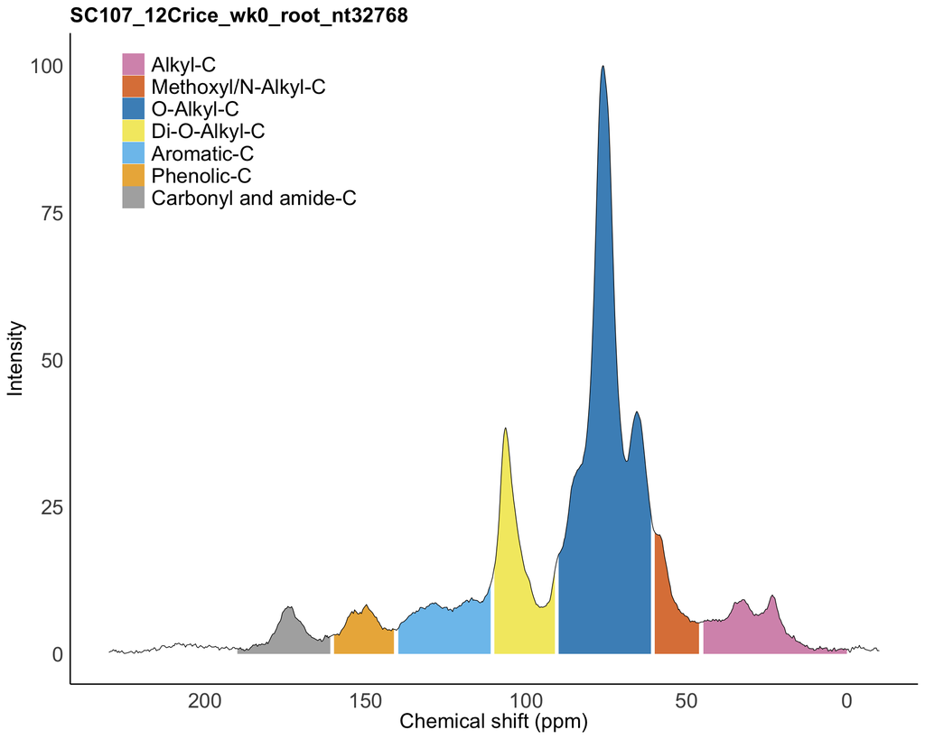

```r
# load necessary packages
  library(ggplot2)
  library(SOMnmR)

# Source the modified plot function using full path
code_folder <- "/Users/adrianneseiden/Documents/adrianne-code"
source(file.path(code_folder, "plot_NMR_edit.R"))

# Set working directory to outputs folder for plot saving
setwd(outputs_folder)

# Generate plots - they will be saved to outputs_folder and displayed in HTML
plot_NMR_aks(spec, NMRmeth = "Bonanomi", file.output = TRUE , use.tiff = FALSE)
```

```r
# Return to original directory
setwd(csv_folder)
```

# Suberin Over Time

Plot the Suberin percentage changes over time for each crop type.

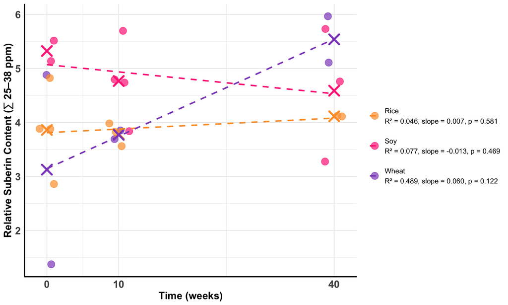

```r
library(ggplot2)
library(dplyr)
library(tidyr)
library(stringr)
library(ggpmisc)

# Extract crop type and timepoint from sample names
Integrall_time <- Integrall %>%
  mutate(
    # Extract crop type (wheat, rice, soy, noPlant)
    crop = case_when(
      str_detect(name, "wheat") ~ "wheat",
      str_detect(name, "rice") ~ "rice",
      str_detect(name, "soy") ~ "soy",
      str_detect(name, "noPlant") ~ "noPlant",
      TRUE ~ NA_character_
    ),
    # Extract timepoint (wk0, wk10, wk40)
    timepoint = str_extract(name, "wk[0-9]+"),
    # Extract numeric week value
    week = as.numeric(str_extract(timepoint, "[0-9]+"))
  ) %>%
  filter(!is.na(crop) & !is.na(week) & crop != "noPlant")

# Define crop colors
# crop_color <- c("soy" = "#FE318E", "rice" = "#FC9D33", "wheat" = "#884EBB")

# Calculate R-squared and p-values for each crop
stats_by_crop <- Integrall_time %>%
  group_by(crop) %>%
  summarise(
    model = list(lm(Suberin ~ week)),
    r_squared = summary(model[[1]])$r.squared,
    slope = coef(model[[1]])[2],
    p_value = summary(model[[1]])$coefficients[2, 4],
    .groups = "drop"
  ) %>%
  mutate(
    label = sprintf("R² = %.3f, slope = %.3f, p = %.3f%s",
                    r_squared, slope, p_value,
                    ifelse(p_value < 0.05, " *", "")),
    crop_label = paste0(toupper(substring(crop, 1, 1)), substring(crop, 2))
  )

# Create labels for legend
legend_labels <- stats_by_crop %>%
  arrange(factor(crop, levels = c("soy", "rice", "wheat"))) %>%
  mutate(full_label = paste0(crop_label, "\n", label)) %>%
  pull(full_label)

names(legend_labels) <- stats_by_crop %>%
  arrange(factor(crop, levels = c("soy", "rice", "wheat"))) %>%
  pull(crop)
# Calculate means for each crop-timepoint combination
sub_means <- Integrall_time %>%
  group_by(crop, week) %>%
  summarise(mean_suberin = mean(Suberin, na.rm = TRUE), .groups = 'drop')
# Create the plot
p <- ggplot(Integrall_time, aes(x = week, y = Suberin, color = crop)) +
  geom_jitter(size = 4.5, alpha = 0.7, width = 1.5) +
  geom_point(data = sub_means, aes(x = week, y = mean_suberin, color = crop),
             shape = 4, size = 5.2, stroke = 2, show.legend = FALSE) +
  geom_smooth(method = "lm", se = FALSE, linetype = "dashed", linewidth = 1) +
  scale_color_manual(
    values = crop_color,
    labels = legend_labels
  ) +
  scale_x_continuous(breaks = c(0, 10, 40)) +
  labs(
    title = NULL,
    x = "Time (weeks)",
    y = "Relative Suberin Content (\u2211 25–38 ppm)",
    color = ""
  ) +
  # theme_dark_custom() +
  theme(
    axis.title = element_text(size = 14.5, face = "bold"),
    axis.text = element_text(size = 14.5, face = "bold"),
    axis.line = element_line(size = 0.8),
    legend.position = "right",
    legend.text = element_text(size = 10, lineheight = 1.2),
    legend.key.height = unit(1.5, "cm")
  )
print(p)
```

```r
# Save the plot
ggsave_themed(filename = "suberin_25-38_by_crop_timepoint.png",
              plot = p, width = 11, height = 7, dpi = 300)
# summarise(
#     n = n(),
#     mean_suberin = round(mean(Suberin, na.rm = TRUE), 3),
#     sd_suberin = round(sd(Suberin, na.rm = TRUE), 3),
#     .groups = "drop"
#   ) %>%
#   knitr::kable() %>%
#   kableExtra::kable_styling()
```

## Statistical Methods in NMR Data Analysis

### 1. **Spectral Integration**

Peak areas are calculated by integrating (summing) the absorbance values within each spectral window.

### 2. **Spinning Sideband (SSB) Correction**

The `region_calc_suberin` function applies a correction algorithm to account for spinning sidebands—artifact peaks that appear around the main NMR signals due to sample rotation during measurement. This correction is essential for accurate quantification of true chemical composition.

### 3. **Linear Regression Analysis (Suberin Over Time)**

Time-series trends in suberin content are analyzed using **simple linear regression** for each crop: - **Model**: `Suberin ~ week` - **Data**: All individual sample measurements (not averaged by timepoint) - **Statistics reported**: - **R²** (coefficient of determination): Proportion of variance in suberin content explained by time - **Slope**: Change in relative suberin content per week - **P-value**: Statistical significance test (α = 0.05); values < 0.05 marked with “*”

This approach uses all available replicate measurements, providing robust statistical inference for temporal trends.

### 5. **Data Processing & Preparation**

- **Name parsing**: Sample identities (crop type and timepoint) are extracted from filenames using pattern matching (e.g., “wheat”, “rice”, “soy”; “wk0”, “wk10”, “wk40”)
- **Filtering**: Data for “noPlant” control samples are excluded from the time-series analysis
- **Numeric conversion**: All integration values are converted to numeric format and standardized

### 6. **Data Visualization**

The suberin plot combines: - **Individual datapoints** (jittered for visibility) - **Mean indicators** (cross symbols at group averages) - **Fitted regression lines** (dashed lines per crop) - **Regression statistics** in the legend (R², slope, p-value per crop)